# GPA Trends and Predictive Modeling

## Introduction

- **Dataset**: Academic Performance of University Student Dataset by Krishnansh Verma (Kaggle)
- **Sample**: Roughly 3000 Undergraduate students with GPA records from first year to graduation
- **Key Variables**:
  - `CGPA100`: First-Year GPA
  - `CGPA`: Final Cumulative GPA
  - `SGPA`: Secondary School GPA
  - `Prog.Code`: Academic Program
- **Goal**: Analyze GPA progression and identify early predictors of Final Cumulative GPA

## Research Questions

1. **How does GPA change across academic years?**
   - Explore GPA distributions from Freshman to Senior year
   - Visualize student performance progression
2. **Can First-Year GPA predict Final GPA?**
   - Fit a linear regression using CGPA100
   - Evaluate strength and significance of the relationship
3. **Does Program of Study significantly affect Final GPA?**
   - Use multiple regression to control for academic background and gender
   - Estimate each program’s adjusted effect compared to the average

## Data Preparation

First the data needs to be reshaped and make it ready for modeling.

```r
gpaData <- read.csv("academic_performance_dataset_V2.csv")

gpaData_long <- gpaData %>%
  pivot_longer(cols = CGPA100:CGPA400,
               names_to = "Year",
               values_to = "Yearly_CGPA") %>%
  mutate(Year = factor(Year,
               levels = c("CGPA100", "CGPA200", "CGPA300", "CGPA400"),
               labels = c("Freshman", "Sophomore", "Junior", "Senior")))
```

Reshaped GPA columns from wide to long format to make it easier to visualize year-by-year GPA trends using ggplot

```r
gpaData <- gpaData %>%
  mutate(
    Program_Name = recode(Prog.Code,
      "CIS" = "Comp Sci", "MIS" = "Mgmt Info Sys", "CHE" = "Chem E", ...),
    Program_Name = factor(Program_Name),
    Gender = factor(Gender))
```

Replaced program codes with descriptive labels and converted categorical variables (Gender, Program) to factors for proper group comparisons in the regression model.

## GPA Distribution by Year

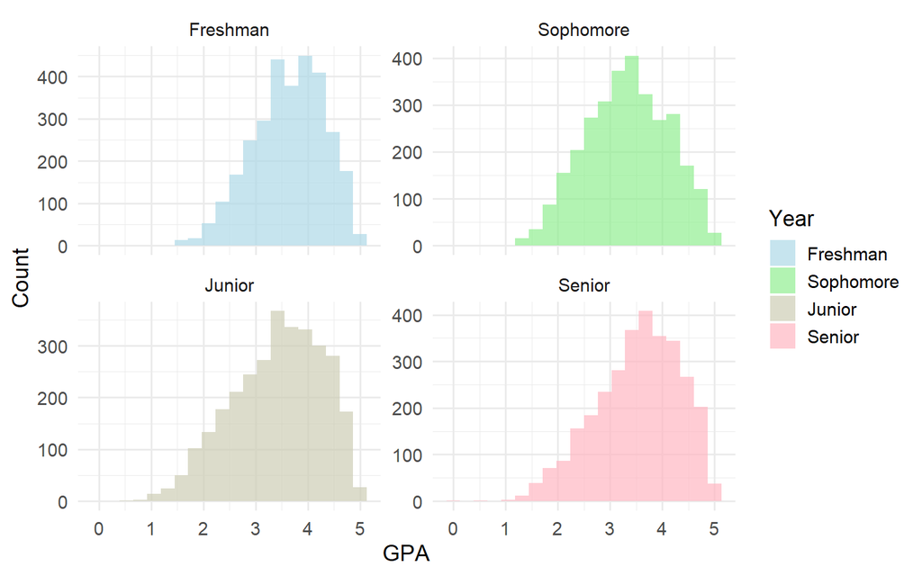

## GPA Progression

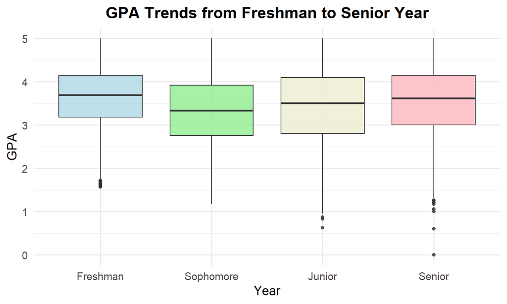

## Predicting Final GPA from First-Year Performance

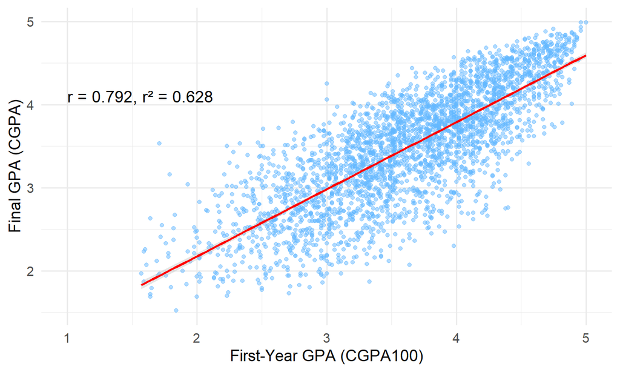

The correlation between First-Year GPA and Final GPA is strong (r = 0.792).  
Each 1-point increase in First-Year GPA is associated with a +0.81-point increase in Final GPA.  
This effect is precise (SE = 0.011) and highly statistically significant (p < 0.001).

## Does Program Matter?

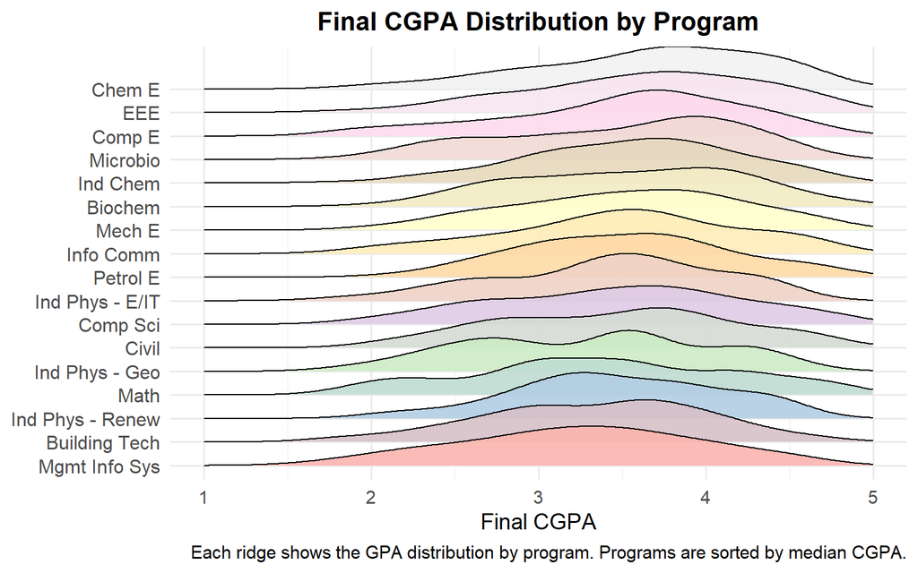

## Do Some Programs Boost GPA More Than Others?

\[ {\scriptsize \text{CGPA} = \beta_0 + \beta_1 \, \text{CGPA100} + \beta_2 \, \text{SGPA} + \beta_3 \, \text{Gender} + \sum_{i=1}^{I-1} \gamma_i \, \text{Program}_{i} + \varepsilon } \]

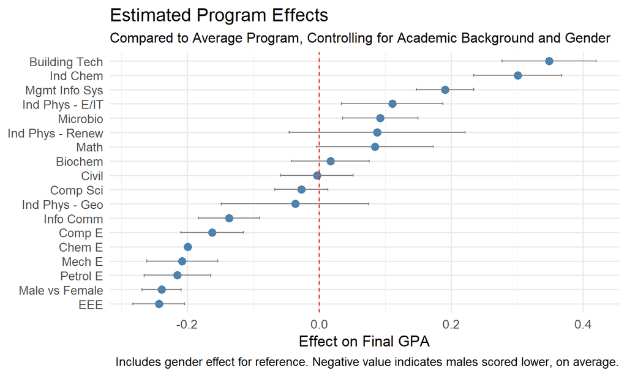

## Conclusions

- **First-Year GPA is a strong predictor of final GPA**
  - Alone, it explains ~63% of the variance (R² = 0.63)
- **Multiple regression improves explanatory power**
  - Adding secondary school GPA, gender, and program increases R² to 0.72
- **Academic background and gender have significant effects**
  - Students with higher secondary school GPAs and freshman year GPAs tend to finish stronger
  - Males had lower final GPAs on average, controlling for other factors
- **Some programs were associated with significantly higher or lower final GPAs (adjusted for background)**
  - Building Technology and Industrial Chemistry: ~0.3 to 0.4 GPA points above the adjusted average
  - Electrical and Petroleum Engineering: ~0.2 to 0.25 GPA points below the adjusted average
  - Effects account for differences in first-year GPA, secondary GPA, and gender